# 다변량분석

김도형

2024-06-10

# League Of Legends 게임데이터 분석 - PCA / SEM / Classification(XGB_CLF)

최근 성장하는 E-Sports 시장 확장에 힘입어, 기존 야구와 같은 고전 스포츠 등에서 활용되던 승리요인 분석 등의 기법들이 리그에 도입되기 시작하였음.

이러한 도입세는 기존 아마추어 플레잉 데이터들을 확보하기 힘들었던 고전 스포츠와는 다른 방식으로 발전, 아마추어들이나 일반인들을 대상으로도 서비스 확장. 가볍게는 승리/패배에 대한 기여도를 분석해주는 사이트들부터, 자세한 컨설팅을 제공해주는 서비스도 생겨남.

이에, 해당 서비스들을 소개하는 것을 겸하여, 프로젝트 주제를 해당 데이터 분석 및 모델 작성으로 결정.

## 개요

#### 1. Riot API를 활용한 데이터 로드(Python) - Tier/Division별로 포지션 무관 약 8천여건의 데이터 확보

#### 2. Proprocessing - Domain knowledge를 활용하여 사용 가능한 컬럼 정제 및 파생 변수 생성

#### 3. PCA를 통한 요인분석(target - win / lose)

#### 4. SEM을 통한 승리요인/티어상승요인(상위티어 위치 요인) 분석

#### 5. XGB Classifier를 통한 승리/패배 classifier 생성

```python
import pandas as pd
import numpy as np
import requests

def get_tier_division_data(tier, division, queue):
    url = f'https://kr.api.riotgames.com/lol/league-exp/v4/entries/{queue}/{tier}/{division}'
    response = requests.get(url, headers=headers)
    return response.json()

def get_summoner_data_by_id(summoner_id):
    url = f'https://kr.api.riotgames.com/lol/summoner/v4/summoners/{summoner_id}'
    response = requests.get(url, headers=headers)
    return response.json()

def get_match_list(puuid):
    url = f'https://asia.api.riotgames.com/lol/match/v5/matches/by-puuid/{puuid}/ids'
    response = requests.get(url, headers=headers)
    return response.json()

def get_match_details(match_id):
    url = f'https://asia.api.riotgames.com/lol/match/v5/matches/{match_id}'
    response = requests.get(url, headers=headers)
    return response.json()

api_key =

headers = {
    'User-Agent' :
    'X-Riot-Token': api_key
}

for tier in tiers:
    print(f'tier: {tier}')
    for division in divisions:
        print(f'division: {division}')
        tier_division_data = get_tier_division_data(tier, division, queue)
        time.sleep(120)

        for i in tier_division_data:
            tier_list.append(i['tier'])
            division_list.append(i['rank'])
            id_list.append(i['summonerId'])
            time.sleep(0.05)

puuid_list = []
for i in range(len(id_list)):
    puuid = get_summoner_data_by_id(id_list[i])['puuid']
    puuid_list.append(puuid)
    if i%20 == 0:
        print(i)
    time.sleep(1.3)

for i in range(5740):
    got_puuid = get_summoner_data_by_id(id_list[i])
    try:
        puuid = got_puuid['puuid']
    except:
        print(f'break :{i}')
        break
    puuid_list.append(puuid)
    if i%20 == 0:
        print(i)
    time.sleep(1.2)

j = 0
match_dict = {}
for puuid in puuid_list:
    match_lists = get_match_list(puuid)

    match_dict[puuid] = match_lists

    time.sleep(1.2)

    j += 1

    if j % 50 == 0:
        print(f'now: {j}')

match_list = pd.DataFrame(match_dict)
match_list.columns = ['puuid', 0, 1, 2, 3, 4, 5, 6, 7, 8, 9, 10, 11, 12, 13, 14, 15, 16, 17, 18, 19]

column_names = []
error_list = []
matches_details = pd.DataFrame()
for j in range(4):
    for i in range(len(matches_details)):
        time.sleep(1.2)
        try:
            if not pd.isnull(matches.iloc[i, j]):
                match_detail = get_match_details(matches.iloc[i, j])

                for match in match_detail['info']['participants']:
                    try:
                        match = match|match['challenges']

                    except:
                        break

                    try:
                        del match['challenges']
                    except:
                        break
                    try:
                        del match['legendaryItemUsed']
                    except:
                        break
                    try:
                        del match['perks']
                    except:
                        break
                    try:
                        del match['missions']
                    except:
                        break

                    match = pd.DataFrame(data=match.values(), index=match.keys())

                    matches_details = pd.concat([matches_details, match], axis=1)
                    column_names.append(f'{i}:{j}th')
            else:
                error_list.append((i, j))
                continue
        except:
            error_list.append((i, j))

        print(i)
```

#### 필요 데이터(인게임 플레잉 데이터) 로드 및 패키지 로드

패키지 : caret, HSAUR2, tools, lavaan, dplyr, xgboost (,+ IRdisplay)

```
## 'data.frame':    221637 obs. of  27 variables:
##  $ assists                    : int  7 3 4 4 7 0 7 5 8 10 ...
##  $ champExperience            : int  12951 12418 12891 10465 10136 15276 14278 13374 9589 10906 ...
##  $ dangerPings                : int  0 0 0 0 0 0 0 0 0 0 ...
##  $ deaths                     : int  3 7 8 6 12 7 5 7 12 5 ...
##  $ dragonKills                : int  0 1 0 0 0 0 1 0 1 0 ...
##  $ enemyMissingPings          : int  6 10 3 12 12 4 0 3 0 3 ...
##  $ goldEarned                 : int  9343 12116 10942 9510 10805 12967 11425 14346 8656 10822 ...
##  $ kills                      : int  3 9 9 4 11 7 3 16 3 7 ...
##  $ lane                       : chr  "JUNGLE" "JUNGLE" "MIDDLE" "BOTTOM" ...
##  $ totalDamageDealtToChampions: int  19286 16300 22617 11302 24027 19018 9846 26700 12941 25650 ...
##  $ gameEndedInSurrender       : chr  "False" "False" "False" "False" ...
##  $ totalTimeCCDealt           : int  218 611 123 29 142 495 285 150 475 46 ...
##  $ win                        : chr  "False" "False" "False" "False" ...
##  $ damagePerMinute            : num  705 595 826 413 878 ...
##  $ enemyJungleMonsterKills    : num  0 11 0 0 0 0 13 2 0 0 ...
##  $ gameLength                 : num  1642 1642 1642 1642 1642 ...
##  $ killParticipation          : num  0.278 0.333 0.361 0.222 0.5 ...
##  $ killsNearEnemyTurret       : num  2 0 2 1 6 3 2 5 1 0 ...
##  $ killsUnderOwnTurret        : num  0 1 1 0 0 0 0 0 1 0 ...
##  $ soloKills                  : num  3 2 8 0 4 4 2 6 0 2 ...
##  $ teamDamagePercentage       : num  0.206 0.174 0.242 0.121 0.257 ...
##  $ visionScorePerMinute       : num  1.237 0.956 0.604 0.392 1.286 ...
##  $ wardTakedowns              : num  2 2 0 2 0 1 1 0 0 13 ...
##  $ wardsGuarded               : num  1 2 0 0 1 0 1 0 0 0 ...
##  $ sightWardsBoughtInGame     : int  0 0 0 0 0 0 0 0 0 0 ...
##  $ Tier                       : chr  "IRON" "IRON" "IRON" "IRON" ...
##  $ Division                   : chr  "IV" "IV" "IV" "IV" ...
## NULL
```

#### PreProcessing

Tier set, Division set, Win set, gameEndedInSurrender(항복으로 게임이 끝났는지 여부) 분리

무의미한 칼럼(sightWardsBoughtInGame, dangerPings) 제거(삭제된 기능)

데이터타입 숫자형(int, num)으로 변환

변수생성((kills, deaths, assists, gold) per minute)

```r
# factor로 변환

df$lane = as.factor(df$lane)
df$Tier = as.factor(df$Tier)
df$Division = as.factor(df$Division)
positions$teamPosition = as.factor(positions$teamPosition)

#이진변수 변환

df$gameEndedInSurrender[df$gameEndedInSurrender == 'True'] = 1
df$gameEndedInSurrender[df$gameEndedInSurrender == 'False'] = 0
df$win[df$win == 'True'] = 1
df$win[df$win == 'False'] = 0
df$win = as.integer(df$win)

# 별도로 필요할 가능성이 있는 데이터 분리

tier = df$Tier
division = df$Division
lane = df$lane
win = df$win
positions = positions$teamPosition

# 무의미한 데이터(gameEndedInSurrender => 항복으로 끝난 게임, sightWardsBoughtInGame, dangerPings => 없어진 시스템) 정리

df$gameEndedInSurrender = as.integer(df$gameEndedInSurrender)
df = subset(df, select = -c(lane, sightWardsBoughtInGame, dangerPings))

# categorical data => ordinal data

df$Tier <- as.numeric(factor(df$Tier, levels = c("IRON", "BRONZE", "SILVER", "GOLD", "PLATINUM", "EMERALD", "DIAMOND")))
df$Division <- as.numeric(factor(df$Division, levels = c("IV", "III", "II", "I")))

df = subset(df, select =- c(gameEndedInSurrender))
df2 = df

# 파생변수 생성

df2$kill_per_minute = df2$kills / df2$gameLength
df2$assists_per_minute = df2$assists / df2$gameLength
df2$death_per_minute = df2$deaths / df2$gameLength
df2$gpm = df2$goldEarned / df2$gameLength
df2$exp_per_minute = df2$champExperience / df2$gameLength
```

target data 분리

Trying PCA

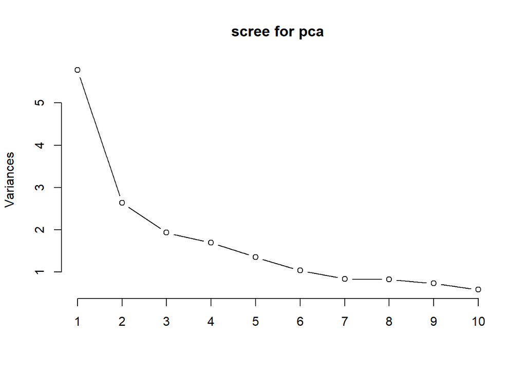

```
##                     assists             champExperience
##                  0.20342049                  0.35272099
##                      deaths                 dragonKills
##                  0.18923876                  0.05197686
##           enemyMissingPings                  goldEarned
##                  0.01207659                  0.38140117
##                       kills totalDamageDealtToChampions
##                  0.36244987                  0.37117492
##            totalTimeCCDealt             damagePerMinute
##                  0.09856198                  0.33239242
##     enemyJungleMonsterKills                  gameLength
##                  0.06325678                  0.18132863
##           killParticipation        killsNearEnemyTurret
##                  0.20672004                  0.23184767
##         killsUnderOwnTurret                   soloKills
##                  0.20035146                  0.18435342
##        teamDamagePercentage        visionScorePerMinute
##                  0.20607773                 -0.10204168
##               wardTakedowns                wardsGuarded
##                  0.00863014                  0.01710483
```

BiPlot

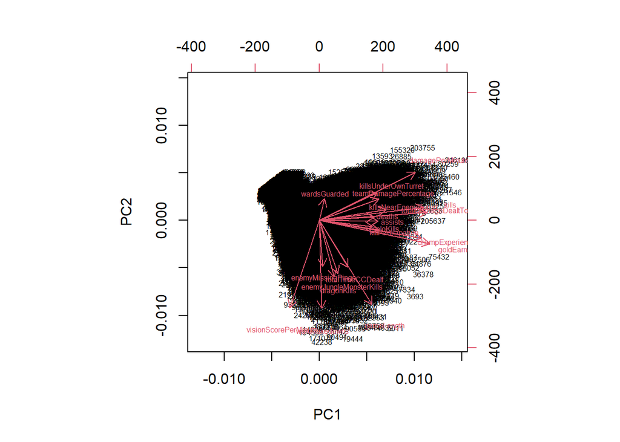

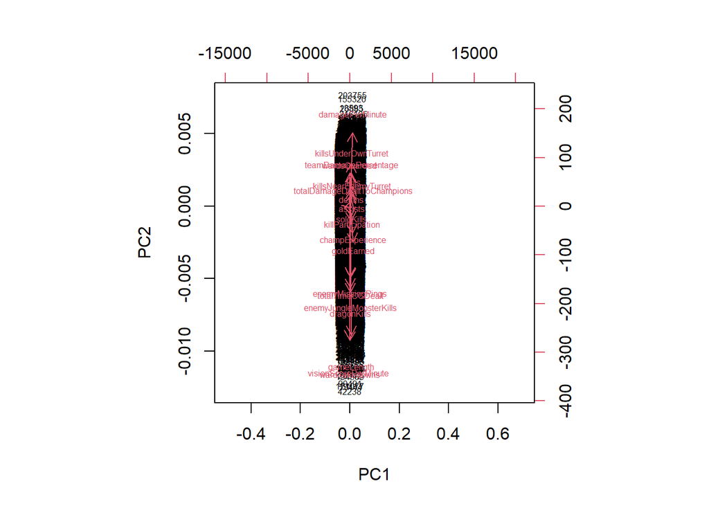

그래프 해석상의 어려움으로(직관적으로 이해되지 않는 부분이 많아) 해석은 하지 않았음.

#### 구조방정식 모델 생성

##### 본 모델에서는 단순한 가법모형을 고려하기로 함.

```r
model_tier = '
  Tier ~ assists_per_minute + exp_per_minute + death_per_minute + dragonKills + enemyMissingPings + gpm + kill_per_minute +
         totalDamageDealtToChampions + totalTimeCCDealt + damagePerMinute + enemyJungleMonsterKills +
         killParticipation + killsNearEnemyTurret + killsUnderOwnTurret + teamDamagePercentage +
         visionScorePerMinute + wardTakedowns + wardsGuarded + Division
'
```

```r
model_win = '
  win ~ assists_per_minute + exp_per_minute + death_per_minute + dragonKills + enemyMissingPings + gpm + kill_per_minute +
         totalDamageDealtToChampions + totalTimeCCDealt + damagePerMinute + enemyJungleMonsterKills +
         killParticipation + killsNearEnemyTurret + killsUnderOwnTurret + teamDamagePercentage +
         visionScorePerMinute + wardTakedowns + wardsGuarded
'
```

#### 인게임 실제에서는 역할군별로, 선택한 챔피언(유닛) 특성별로 다양한 승리 요인이 기대되나, 분석의 편의를 위해 해당 프로젝트에서는 단일 역할군만을 분석.

```r
mid_df <- mid_df %>% select(-position)

scaled_df_mid = subset(mid_df, select =-c(Tier, Division, win))
```

```r
scaled_df_mid = as.data.frame(scale(scaled_df_mid))

scaled_df_mid$Tier = mid_df$Tier
scaled_df_mid$Division = mid_df$Division
scaled_df_mid$win = mid_df$win

scaled_df_mid_tier = as.data.frame(scaled_df_mid)
scaled_df_mid_win = as.data.frame(scaled_df_mid)

suppressWarnings({
  fit_mid_tier <- sem(model_tier, data = scaled_df_mid)
})

suppressWarnings({
  fit_mid_win <- sem(model_win, data = scaled_df_mid)
})
```

```r
summary(fit_mid_tier, standardized = TRUE)
```

```
## lavaan 0.6.17 ended normally after 1 iteration
##
##   Estimator                                         ML
##   Optimization method                           NLMINB
##   Number of model parameters                        20
##
##   Number of observations                         35367
##
## Model Test User Model:
##
##   Test statistic                                 0.000
##   Degrees of freedom                                 0
##
## Parameter Estimates:
##
##   Standard errors                             Standard
##   Information                                 Expected
##   Information saturated (h1) model          Structured
##
## Regressions:
##                    Estimate  Std.Err  z-value  P(>|z|)   Std.lv  Std.all
##   Tier ~
##     assists_pr_mnt    0.001    0.013    0.063    0.950    0.001    0.000
##     exp_per_minute   -0.264    0.016  -16.210    0.000   -0.264   -0.130
##     death_per_mint    0.110    0.011    9.899    0.000    0.110    0.054
##     dragonKills      -0.055    0.010   -5.448    0.000   -0.055   -0.027
##     enemyMssngPngs   -0.057    0.010   -5.600    0.000   -0.057   -0.028
##     gpm               1.018    0.022   46.608    0.000    1.018    0.499
##     kill_per_minut   -0.829    0.023  -36.342    0.000   -0.829   -0.406
##     ttlDmgDltTChmp   -1.113    0.029  -37.878    0.000   -1.113   -0.545
##     totalTimeCCDlt    0.069    0.011    6.333    0.000    0.069    0.034
##     damagePerMinut    0.988    0.039   25.591    0.000    0.988    0.484
##     enmyJnglMnstrK   -0.099    0.011   -9.312    0.000   -0.099   -0.048
##     killParticiptn    0.180    0.015   11.950    0.000    0.180    0.088
##     kllsNrEnmyTrrt   -0.111    0.014   -7.749    0.000   -0.111   -0.054
##     kllsUndrOwnTrr   -0.015    0.011   -1.328    0.184   -0.015   -0.007
##     teamDamgPrcntg   -0.147    0.015   -9.782    0.000   -0.147   -0.072
##     visionScrPrMnt    0.292    0.012   23.449    0.000    0.292    0.143
##     wardTakedowns     0.306    0.012   24.575    0.000    0.306    0.150
##     wardsGuarded      0.063    0.010    6.229    0.000    0.063    0.031
##     Division         -0.010    0.009   -1.084    0.278   -0.010   -0.005
##
## Variances:
##                    Estimate  Std.Err  z-value  P(>|z|)   Std.lv  Std.all
##    .Tier              3.432    0.026  132.979    0.000    3.432    0.824
```

```r
summary(fit_mid_win, standardized = TRUE)
```

```
## lavaan 0.6.17 ended normally after 1 iteration
##
##   Estimator                                         ML
##   Optimization method                           NLMINB
##   Number of model parameters                        19
##
##   Number of observations                         35367
##
## Model Test User Model:
##
##   Test statistic                                 0.000
##   Degrees of freedom                                 0
##
## Parameter Estimates:
##
##   Standard errors                             Standard
##   Information                                 Expected
##   Information saturated (h1) model          Structured
##
## Regressions:
##                    Estimate  Std.Err  z-value  P(>|z|)   Std.lv  Std.all
##   win ~
##     assists_pr_mnt    0.237    0.003   93.063    0.000    0.237    0.474
##     exp_per_minute    0.061    0.003   19.624    0.000    0.061    0.122
##     death_per_mint   -0.125    0.002  -59.568    0.000   -0.125   -0.251
##     dragonKills       0.019    0.002   10.078    0.000    0.019    0.039
##     enemyMssngPngs   -0.008    0.002   -4.359    0.000   -0.008   -0.017
##     gpm               0.061    0.004   14.694    0.000    0.061    0.122
##     kill_per_minut    0.187    0.004   43.131    0.000    0.187    0.375
##     ttlDmgDltTChmp   -0.039    0.006   -6.970    0.000   -0.039   -0.078
##     totalTimeCCDlt   -0.007    0.002   -3.372    0.001   -0.007   -0.014
##     damagePerMinut   -0.019    0.007   -2.571    0.010   -0.019   -0.038
##     enmyJnglMnstrK    0.028    0.002   13.831    0.000    0.028    0.056
##     killParticiptn   -0.230    0.003  -80.464    0.000   -0.230   -0.461
##     kllsNrEnmyTrrt    0.025    0.003    9.115    0.000    0.025    0.050
##     kllsUndrOwnTrr   -0.040    0.002  -19.044    0.000   -0.040   -0.080
##     teamDamgPrcntg   -0.000    0.003   -0.041    0.968   -0.000   -0.000
##     visionScrPrMnt    0.010    0.002    4.056    0.000    0.010    0.019
##     wardTakedowns    -0.006    0.002   -2.505    0.012   -0.006   -0.012
##     wardsGuarded     -0.006    0.002   -2.996    0.003   -0.006   -0.012
##
## Variances:
##                    Estimate  Std.Err  z-value  P(>|z|)   Std.lv  Std.all
##    .win               0.124    0.001  132.979    0.000    0.124    0.497
```

대체로 win~ 모델에서는 게이머들 사이에서 보편적으로 받아들여질 수 있는 결과가 도출, tier~ 모델에서는 일부는 당연납득 가능하지만 일부는 아닌 결과가 도출.

실력대별로 동일한 수준의 상대와 매칭이 이루어지므로 지표상 큰 차이가 나지는 않을 수 있음. 실력대별로 게임 양상이 다르다는 의미로 일단 해석. 추후 ANOVA 등으로 심도있는 분석이 필요할 것으로 사료됨.

#### XGBoost Classifier

##### XGB_clf for win

```r
# random sample
train_idx = sample(1:nrow(scaled_df_mid), 0.75 * nrow(scaled_df_mid))

train_data = scaled_df_mid[train_idx, ]
test_data = scaled_df_mid[-train_idx, ]

# label detach
train_labels = as.numeric(train_data$win)
test_labels = as.numeric(test_data$win)

# train & test data set
train_matrix = as.matrix(train_data[, -28])
test_matrix = as.matrix(test_data[, -28])

dtrain = xgb.DMatrix(data = train_matrix, label=train_labels)
dtest = xgb.DMatrix(data = test_matrix, label=test_labels)

# hyperparameter setting
params = list(
  objective = "binary:logistic",  # binary
  eval_metric = "error",
  max_depth = 8
)

# model fitting
xgb_clf = xgboost(
  param = params,
  data = dtrain,
  nrounds = 100,  # 트리 생성 횟수
  verbose = 0,
  eta=0.1
)

pred = predict(xgb_clf, dtest)
preds = ifelse(pred > 0.5, 1, 0)

conf_mat = table(preds, test_labels)

print(conf_mat)
```

```
##      test_labels
## preds    0    1
##     0 3792  550
##     1  616 3884
```

##### xgb_clf for tiers

```r
train_idx = sample(1:nrow(scaled_df_mid), 0.75 * nrow(scaled_df_mid))

train_data = scaled_df_mid[train_idx, ]
test_data = scaled_df_mid[-train_idx, ]

train_labels = as.numeric(train_data$Tier)-1
test_labels = as.numeric(test_data$Tier)-1

train_matrix = as.matrix(train_data[, -26])
test_matrix = as.matrix(test_data[, -26])

dtrain = xgb.DMatrix(data = train_matrix, label=train_labels)
dtest = xgb.DMatrix(data = test_matrix, label=test_labels)

params = list(
  objective = "multi:softmax",
  eval_metric = "merror",
  max_depth = 8,
  num_class=7
)

# 모델 훈련
xgb_clf = xgboost(
  param = params,
  data = dtrain,
  nrounds = 100,
  verbose = 0,
  eta = 0.1
)

pred = predict(xgb_clf, dtest)
```

##### conf_matrix for multi-classes(모델 평가를 위함)

```r
pred_transformed = factor(pred, levels = c(0, 1, 2, 3, 4, 5, 6),
                           labels = c("IRON", "BRONZE", "SILVER", "GOLD", "PLATINUM", "EMERALD", "DIAMOND"))

label_transformed = factor(test_labels, levels = c(0, 1, 2, 3, 4, 5, 6),
                           labels = c("IRON", "BRONZE", "SILVER", "GOLD", "PLATINUM", "EMERALD", "DIAMOND"))

conf_mat = table(pred_transformed, label_transformed)

print(conf_mat)
```

```
##                 label_transformed
## pred_transformed IRON BRONZE SILVER GOLD PLATINUM EMERALD DIAMOND
##         IRON      761    411    306  219      149     131     113
##         BRONZE    199    252    182  151      106     102     101
##         SILVER    167    207    262  225      179     135     130
##         GOLD       81    138    138  275      123     122     110
##         PLATINUM   33     38     67   41      112      30      49
##         EMERALD    55     95    128  111      122     183     157
##         DIAMOND   119    175    236  288      270     347     711
```

```r
accuracy = sum(diag(conf_mat))/sum(conf_mat)

print(accuracy)
```

```
## [1] 0.2890749
```

```r
class_accuracy <- diag(conf_mat) / colSums(conf_mat)
cat("classy_accuracy", class_accuracy)
```

```
## classy_accuracy 0.5378092 0.1914894 0.1986353 0.2099237 0.1055608 0.1742857 0.5185996
```

win~ 모델은 꽤 괜찮은 성능을 보이나, tier~ 모델은 없는 것 보다는 살짝 나은 성능을 보임.

binary 모델보다 multi class가 성능이 떨어지는 것은 이상한 일은 아니나, 그럼에도 불구하고 사용을 위해서는 보다 적극적인 hyper parameter 세팅과 더 큰 데이터셋, 더 정밀한 preprocessing 및 column selection이 요구되는 것으로 사료.